```python
import pandas as pd
import matplotlib.pyplot as plt
from matplotlib_scalebar.scalebar import ScaleBar
import numpy as np
import requests
import geopandas as gpd
from shapely.geometry import Point
import folium
from esda import moran
import libpysal
```

# The Green Effect: Investigating the Green Gentrification in East London

# Context and Problem

This essay describes the effect of the "Green Paradox"; environmental gentrification caused by "Green Projects", including but not limited to: park restorations, wetland projects, or "blandscaping". Urban Greening is often described as a "universal win" for the public and climate, however, this "Green Paradox" inadvertently drives up property values, displacing lower-income and long-term residents ([Gould & Lewis, 2017](https://www.taylorfrancis.com/books/mono/10.4324/9781315687322/green-gentrification-kenneth-gould-tammy-lewis)). Scholars have often argued for a "just green enough" strategy to mitigate these effects, yet the pressure of ecological attraction remains a significant driver of urban displacement.

One project which comes to mind is the Queen Elizabeth Olympic Park. Consequently, East London house prices rose ~64% between 2012 and 2017 ([Halifax, 2017](https://www.thesun.co.uk/money/4161383/house-prices-east-london-doubled-since-2012-three-times-faster-than-uk-average/)), outperforming the rest of the capital. Additionally, house prices in Waltham Forest grew 122% in the 10 years since the Olympics, representing the ever-growing rent gap coined not by industrial development but by ecological aestheticization ([Smith, 1987](https://onlinelibrary.wiley.com/doi/abs/10.1111/j.1467-8306.1987.tb00171.x)). As outlined by [Lloyds Bank (2022)](https://www.thesun.co.uk/money/4161383/house-prices-east-london-doubled-since-2012-three-times-faster-than-uk-average/), these shifts highlight the complex intersection of environmental planning and social equity, where sustainability initiatives can inadvertently become tools of exclusion.

As such, my research explores the relationship between green space density and socio-economic shift in and around London. By utilising Geospatial tools, I will visualise the distribution of parks (via OpenStreetMap Overpass API) against indices of multiple deprivation (IMD) and housing costs. This technical approach allows for a granular analysis of how "green lungs" in a city can also drive displacement through a process of ecological exclusion ([Wolch et al., 2014](https://www.sciencedirect.com/science/article/pii/S0169204614000310); [Immergluck & Balan, 2018](https://www.tandfonline.com/doi/full/10.1080/02723638.2017.1360041); [James, 2005](https://onlinelibrary.wiley.com/doi/abs/10.1111/j.1540-6210.2005.00475.x)). Ultimately, the map aims to provide a critical lens on the "Green Paradox" within the context of London’s evolving urban landscape.

```python
london_data_shapefile = 'statistical-gis-boundaries-london\statistical-gis-boundaries-london\ESRI\London_Borough_Excluding_MHW.shp'
london_gdf = gpd.read_file(london_data_shapefile)
```

```python
#Print the few rows of geopandas dataframe
print(london_gdf.head())
```

```
                   NAME   GSS_CODE   HECTARES  NONLD_AREA ONS_INNER SUB_2009  \
0  Kingston upon Thames  E09000021   3726.117       0.000         F     None
1               Croydon  E09000008   8649.441       0.000         F     None
2               Bromley  E09000006  15013.487       0.000         F     None
3              Hounslow  E09000018   5658.541      60.755         F     None
4                Ealing  E09000009   5554.428       0.000         F     None

  SUB_2006                                           geometry
0     None  POLYGON ((516401.6 160201.8, 516407.3 160210.5...
1     None  POLYGON ((535009.2 159504.7, 535005.5 159502, ...
2     None  POLYGON ((540373.6 157530.4, 540361.2 157551.9...
3     None  POLYGON ((521975.8 178100, 521967.7 178096.8, ...
4     None  POLYGON ((510253.5 182881.6, 510249.9 182886, ...
```

```python
land_house_prices = pd.read_csv('land-registry-house-prices-borough.csv')
land_house_prices.head()
```

|  | Code | Area | Year | Measure | Value |
| --- | --- | --- | --- | --- | --- |
| 0 | E09000001 | City of London | Year ending Dec 1995 | Median | 105,000 |
| 1 | E09000002 | Barking and Dagenham | Year ending Dec 1995 | Median | 49,000 |
| 2 | E09000003 | Barnet | Year ending Dec 1995 | Median | 85,125 |
| 3 | E09000004 | Bexley | Year ending Dec 1995 | Median | 62,000 |
| 4 | E09000005 | Brent | Year ending Dec 1995 | Median | 68,000 |

```python
# 3. CLEANING: Ensure the 'Borough Name' column looks the same in both
# (e.g. both are "Hackney" not "hackney " or "London Borough of Hackney")
# Strip whitespace and convert to title case
land_house_prices['Area'] = land_house_prices['Area'].str.strip().str.title()
london_gdf['NAME'] = london_gdf['NAME'].str.strip().str.title()

# Convert Value to numeric (As it contained commas, remove commas)
land_house_prices['Value'] = land_house_prices['Value'].astype(str).str.replace(',', '').astype(float)

# Filter for 'Mean' measure and calculate the average price across all years for each borough
mean_prices = land_house_prices[land_house_prices['Measure'] == 'Mean']
avg_prices_by_borough = mean_prices.groupby('Area')['Value'].mean().reset_index()
avg_prices_by_borough = avg_prices_by_borough.rename(columns={'Value': 'AveragePrice'})
```

```python
#Merge the two dataframes on the borough name
merged_gdf = london_gdf.merge(avg_prices_by_borough, left_on='NAME', right_on='Area')
print(merged_gdf.columns)
```

```
Index(['NAME', 'GSS_CODE', 'HECTARES', 'NONLD_AREA', 'ONS_INNER', 'SUB_2009',
       'SUB_2006', 'geometry', 'Area', 'AveragePrice'],
      dtype='object')
```

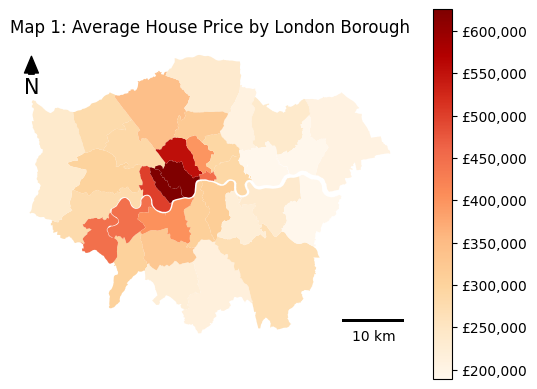

```python
import matplotlib.ticker as ticker
from matplotlib_scalebar.scalebar import ScaleBar

# Calculate quantiles to tighten the color ramp (removes extreme outliers from color scale)
vmin_price = merged_gdf['AveragePrice'].quantile(0.05)
vmax_price = merged_gdf['AveragePrice'].quantile(0.95)

# Plot the average house price by borough
ax = merged_gdf.plot(
    column='AveragePrice',
    cmap='OrRd',
    legend=True,
    vmin=vmin_price,
    vmax=vmax_price,
    legend_kwds={'format': ticker.StrMethodFormatter('£{x:,.0f}')} # Format with commas and £, removes 1e6
)

# Add Scalebar (assuming CRS is EPSG:27700 where 1 unit = 1 meter)
scalebar = ScaleBar(1, units='m', location='lower right')
ax.add_artist(scalebar)

# Add North Arrow
ax.annotate('N', xy=(0.05, 0.95), xytext=(0.05, 0.85),
            arrowprops=dict(facecolor='black', width=4, headwidth=10),
            ha='center', va='center', fontsize=15, xycoords='axes fraction')

ax.set_axis_off() # Remove the x and y axis
plt.title('Map 1: Average House Price by London Borough')
plt.show()
```

```python
#Get the IDACI data, clean it, and merge it with the geodataframe
imd_data = pd.read_csv('File_7_-_All_IoD2019_Scores__Ranks__Deciles_and_Population_Denominators_3.csv')
imd_data
```

|  | LSOA code (2011) | LSOA name (2011) | Local Authority District code (2019) | Local Authority District name (2019) | Index of Multiple Deprivation (IMD) Score | Index of Multiple Deprivation (IMD) Rank (where 1 is most deprived) | Index of Multiple Deprivation (IMD) Decile (where 1 is most deprived 10% of LSOAs) | Income Score (rate) | Income Rank (where 1 is most deprived) | Income Decile (where 1 is most deprived 10% of LSOAs) | ... | Indoors Sub-domain Rank (where 1 is most deprived) | Indoors Sub-domain Decile (where 1 is most deprived 10% of LSOAs) | Outdoors Sub-domain Score | Outdoors Sub-domain Rank (where 1 is most deprived) | Outdoors Sub-domain Decile (where 1 is most deprived 10% of LSOAs) | Total population: mid 2015 (excluding prisoners) | Dependent Children aged 0-15: mid 2015 (excluding prisoners) | Population aged 16-59: mid 2015 (excluding prisoners) | Older population aged 60 and over: mid 2015 (excluding prisoners) | Working age population 18-59/64: for use with Employment Deprivation Domain (excluding prisoners) |
| --- | --- | --- | --- | --- | --- | --- | --- | --- | --- | --- | --- | --- | --- | --- | --- | --- | --- | --- | --- | --- | --- |
| 0 | E01000001 | City of London 001A | E09000001 | City of London | 6.208 | 29199 | 9 | 0.007 | 32831 | 10 | ... | 16364 | 5 | 1.503 | 1615 | 1 | 1296 | 175 | 656 | 465 | 715 |
| 1 | E01000002 | City of London 001B | E09000001 | City of London | 5.143 | 30379 | 10 | 0.034 | 29901 | 10 | ... | 22676 | 7 | 1.196 | 2969 | 1 | 1156 | 182 | 580 | 394 | 620 |
| 2 | E01000003 | City of London 001C | E09000001 | City of London | 19.402 | 14915 | 5 | 0.086 | 18510 | 6 | ... | 17318 | 6 | 2.207 | 162 | 1 | 1350 | 146 | 759 | 445 | 804 |
| 3 | E01000005 | City of London 001E | E09000001 | City of London | 28.652 | 8678 | 3 | 0.211 | 6029 | 2 | ... | 25218 | 8 | 1.769 | 849 | 1 | 1121 | 229 | 692 | 200 | 683 |
| 4 | E01000006 | Barking and Dagenham 016A | E09000002 | Barking and Dagenham | 19.837 | 14486 | 5 | 0.117 | 14023 | 5 | ... | 14745 | 5 | 0.969 | 4368 | 2 | 2040 | 522 | 1297 | 221 | 1285 |
| ... | ... | ... | ... | ... | ... | ... | ... | ... | ... | ... | ... | ... | ... | ... | ... | ... | ... | ... | ... | ... | ... |
| 32839 | E01033764 | Liverpool 022E | E08000012 | Liverpool | 74.468 | 116 | 1 | 0.470 | 90 | 1 | ... | 19468 | 6 | 0.750 | 6052 | 2 | 2712 | 540 | 1584 | 588 | 1625 |
| 32840 | E01033765 | Liverpool 061D | E08000012 | Liverpool | 59.599 | 945 | 1 | 0.362 | 838 | 1 | ... | 24583 | 8 | 0.283 | 10977 | 4 | 1445 | 257 | 902 | 286 | 908 |
| 32841 | E01033766 | Liverpool 042G | E08000012 | Liverpool | 21.895 | 12842 | 4 | 0.099 | 16430 | 6 | ... | 1063 | 1 | 0.629 | 7151 | 3 | 1054 | 170 | 749 | 135 | 735 |
| 32842 | E01033767 | Liverpool 050J | E08000012 | Liverpool | 66.704 | 422 | 1 | 0.396 | 442 | 1 | ... | 1026 | 1 | 0.417 | 9286 | 3 | 1019 | 164 | 655 | 200 | 650 |
| 32843 | E01033768 | Liverpool 037F | E08000012 | Liverpool | 52.286 | 1833 | 1 | 0.273 | 3107 | 1 | ... | 2157 | 1 | 0.913 | 4736 | 2 | 1281 | 91 | 1066 | 124 | 1077 |

32844 rows × 57 columns

```python
#Clean the IMD data, so that the borough names match those in the geodataframe
imd_data['Local Authority District name (2019)'] = imd_data['Local Authority District name (2019)'].str.strip().str.title()
london_gdf['NAME'] = london_gdf['NAME'].str.strip().str.title()

# IMD data is usually at the LSOA (neighborhood) level, meaning there are multiple rows per borough.
# We need to group by the borough name and calculate the average IMD score before merging.
borough_imd = imd_data.groupby('Local Authority District name (2019)')['Index of Multiple Deprivation (IMD) Score'].mean().reset_index()

#Perform a merge on borough name with the aggregated IMD data
merged_gdf = london_gdf.merge(borough_imd, left_on='NAME', right_on='Local Authority District name (2019)')
print(merged_gdf.columns)
```

```
Index(['NAME', 'GSS_CODE', 'HECTARES', 'NONLD_AREA', 'ONS_INNER', 'SUB_2009',
       'SUB_2006', 'geometry', 'Local Authority District name (2019)',
       'Index of Multiple Deprivation (IMD) Score'],
      dtype='object')
```

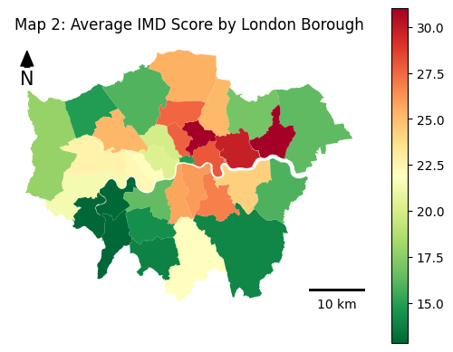

```python
from matplotlib_scalebar.scalebar import ScaleBar

# Calculate quantiles to tighten the color ramp
vmin_imd = merged_gdf['Index of Multiple Deprivation (IMD) Score'].quantile(0.05)
vmax_imd = merged_gdf['Index of Multiple Deprivation (IMD) Score'].quantile(0.95)

# Now we can plot the IMD data from the merged geodataframe
ax = merged_gdf.plot(
    column='Index of Multiple Deprivation (IMD) Score',
    cmap='RdYlGn_r', # Red for high deprivation, Green for low deprivation
    legend=True,
    vmin=vmin_imd,
    vmax=vmax_imd,
    legend_kwds={'format': ticker.StrMethodFormatter('{x:,.1f}')} # Format nicely
)

# Add Scalebar
scalebar = ScaleBar(1, units='m', location='lower right')
ax.add_artist(scalebar)

# Add North Arrow
ax.annotate('N', xy=(0.05, 0.95), xytext=(0.05, 0.85),
            arrowprops=dict(facecolor='black', width=4, headwidth=10),
            ha='center', va='center', fontsize=15, xycoords='axes fraction')


ax.set_axis_off() # Removes the x and y axis numbers/ticks
plt.title('Map 2: Average IMD Score by London Borough')
plt.show()
```

# Map Analysis

There is a clear contrast of the two static maps above which establishes the groundwork for the "Green Paradox" in London. Map 1 shows that property wealth is historically & heavily concentrated in Central & West London (e.g., Kensington, Westminster). Conversely, Map 2 also shows a stark spatial dichotomy, with the highest levels of structural vulnerability (dark red IMD scores) clustered in the East London boroughs, specifically Newham, Hackney, Tower Hamlets and Barking & Dagenham.

In geographic terms, this inverse relationship via spatial autocorrelation between high deprivation and low initial property values represents a massive "rent gap" (Smith, 1987). These eastern boroughs (historically underinvested and vulnerable) became "ground zero" for the "green projects" i.e. 2012 Olympic regeneration. When aggressive "green" infrastructure is injected into such areas, consequently triggering rapid price growth. The vulnerable populations highlighted in Map 2 are therefore the most at risk of ecological displacement as the relatively cheaper housing in Map 1 becomes premium, "green-adjacent" real estate.

# Presenting and Motivating Data Sources

1. Socio-Economic Vulnerability (**IMD** 2019 Data):  
To understand *who* is at risk of displacement, I used the **Index of Multiple Deprivation (IMD)** metric at the Local Authority District level. Rather than relying solely on income, **IMD** provides a robust, composite measure of structural vulnerability, encompassing health, education, and living environment in one. This dataset is crucial for identifying the historically marginalised communities in East London that are most susceptible to ecological exclusion.

2. Economic Displacement (UK House Price / **Land Registry** Data):  
To quantify the economic reality of gentrification, I incorporated average house price data. By mapping the cost of housing alongside **IMD**, we can visualise the "rent gap." This data acts as the ultimate proxy for displacement pressure, highlighting where the cost of living is rapidly outpacing the socioeconomic capacity of the original residents.

3. Environmental Interventions (**OpenStreetMap** API):  
As government data is often temporally lagged, measuring green gentrification requires dynamic, real-time data. As such, I will utilise the **OpenStreetMap (OSM)** Overpass API to map the "Green" interventions. **OSM** provides highly granular vector data, capturing everything from the massive Queen Elizabeth Olympic Park down to localised "pocket parks."

Together, the **IMD** dataset in tandem with UK house price data and the **OpenStreetMap** API allows us to test the spatial correlation between the injection of new green projects (**OSM**) and the capturing of economic pressures (House Prices) on vulnerable populations (**IMD**).

# API and Backend Request

```python
# Multiple public Overpass API mirrors — tried in order if one times out
OVERPASS_ENDPOINTS = [
    "https://overpass.kumi.systems/api/interpreter",
    "https://maps.mail.ru/osm/tools/overpass/api/interpreter",
    "http://overpass-api.de/api/interpreter",
]

def get_london_parks(Borough) -> gpd.GeoDataFrame:
    """
    Fetches the realtime park data for a given London borough using the Overpass API.
    Step 1: Nominatim resolves the borough name → correct OSM relation ID by finding
            the administrative boundary (class=boundary, type=administrative).
    Step 2: Overpass uses that area ID to fetch all parks within the borough boundary.
            Falls back through multiple Overpass mirrors if one times out.
    """
    headers = {'User-Agent': 'LondonGreenGentrificationStudy/1.0'}

    # ── Step 1: Resolve the borough's OSM relation via Nominatim ──────────────
    nominatim_url = "https://nominatim.openstreetmap.org/search"
    nom_params = {
        'q': f'{Borough}, London, United Kingdom',
        'format': 'json',
        'limit': 10,
        'addressdetails': 1,
    }

    try:
        nom_resp = requests.get(nominatim_url, params=nom_params, headers=headers, timeout=15)
        nom_resp.raise_for_status()
        nom_data = nom_resp.json()

        if not nom_data:
            print(f"Nominatim could not find borough: '{Borough}'")
            return gpd.GeoDataFrame(columns=['name', 'geometry'])

        # Pick the first result that is an administrative boundary relation
        boundary = next(
            (r for r in nom_data
             if r.get('osm_type') == 'relation'
             and r.get('class') == 'boundary'
             and r.get('type') == 'administrative'),
            None
        )

        if boundary is None:
            print(f"No administrative boundary relation found for '{Borough}'.")
            return gpd.GeoDataFrame(columns=['name', 'geometry'])

        osm_id  = int(boundary['osm_id'])
        area_id = osm_id + 3_600_000_000   # Overpass area ID for a relation
        print(f"Nominatim resolved '{Borough}' → OSM relation {osm_id} (area id: {area_id})")

    except requests.exceptions.RequestException as e:
        print(f"Nominatim error: {e}")
        return gpd.GeoDataFrame(columns=['name', 'geometry'])

    # ── Step 2: Fetch parks from Overpass (try each mirror in turn) ────────────
    query = f"""
    [out:json][timeout:90];
    area(id:{area_id})->.searchArea;
    (
      node["leisure"="park"](area.searchArea);
      way["leisure"="park"](area.searchArea);
      relation["leisure"="park"](area.searchArea);
    );
    out center;
    """

    data = None
    for endpoint in OVERPASS_ENDPOINTS:
        try:
            print(f"Trying Overpass endpoint: {endpoint}")
            response = requests.get(endpoint, params={'data': query}, timeout=60)
            response.raise_for_status()
            data = response.json()
            print(f"Success with: {endpoint}")
            break
        except requests.exceptions.RequestException as e:
            print(f"  → failed ({e.__class__.__name__}), trying next...")

    if data is None:
        print("All Overpass endpoints failed.")
        return gpd.GeoDataFrame(columns=['name', 'geometry'])

    elements = data.get('elements', [])
    print(f"Overpass returned {len(elements)} park elements for '{Borough}'")

    parks_list = []
    for element in elements:
        name = element.get('tags', {}).get('name', 'Unnamed Park')

        if element['type'] == 'node':
            lat = element.get('lat')
            lon = element.get('lon')
        elif element['type'] in ['way', 'relation']:
            center = element.get('center', {})
            lat = center.get('lat')
            lon = center.get('lon')
        else:
            continue

        if lat is not None and lon is not None:
            parks_list.append({'name': name, 'geometry': Point(lon, lat)})

    if not parks_list:
        print(f"No parks found for borough: {Borough}")
        return gpd.GeoDataFrame(columns=['name', 'geometry'])

    parks_gdf = gpd.GeoDataFrame(parks_list, geometry='geometry')
    parks_gdf.set_crs(epsg=4326, inplace=True)
    return parks_gdf
```

```python
# Example usage: List of boroughs to investigate for Green Gentrification
borough_names = ["Hackney", "Kensington and Chelsea", "Tower Hamlets", "Newham", "Waltham Forest"]
parks_dict = {}

for b in borough_names:
    print(f"Fetching parks for {b}...")
    gdf = get_london_parks(b)
    if gdf is not None and not gdf.empty:
        parks_dict[b] = gdf
        print(f'Total parks fetched for {b}: {len(gdf)}')

# # Quick matplotlib preview
# fig, ax = plt.subplots(figsize=(10, 8))
# colors = ['green', 'blue', 'red', 'purple', 'orange']
# for i, (b, gdf) in enumerate(parks_dict.items()):
#     gdf.plot(ax=ax, marker='*', color=colors[i % len(colors)], markersize=50, alpha=0.6, label=b)
# ax.set_axis_off()
# plt.title('Parks in Selected Boroughs')
# plt.legend()
# plt.show()
```

```
Fetching parks for Hackney...
Nominatim resolved 'Hackney' → OSM relation 51806 (area id: 3600051806)
Trying Overpass endpoint: https://overpass.kumi.systems/api/interpreter
Success with: https://overpass.kumi.systems/api/interpreter
Overpass returned 86 park elements for 'Hackney'
Total parks fetched for Hackney: 86
Fetching parks for Kensington and Chelsea...
Nominatim resolved 'Kensington and Chelsea' → OSM relation 51793 (area id: 3600051793)
Trying Overpass endpoint: https://overpass.kumi.systems/api/interpreter
Success with: https://overpass.kumi.systems/api/interpreter
Overpass returned 31 park elements for 'Kensington and Chelsea'
Total parks fetched for Kensington and Chelsea: 31
Fetching parks for Tower Hamlets...
Nominatim resolved 'Tower Hamlets' → OSM relation 51805 (area id: 3600051805)
Trying Overpass endpoint: https://overpass.kumi.systems/api/interpreter
  → failed (JSONDecodeError), trying next...
Trying Overpass endpoint: https://maps.mail.ru/osm/tools/overpass/api/interpreter
Success with: https://maps.mail.ru/osm/tools/overpass/api/interpreter
Overpass returned 233 park elements for 'Tower Hamlets'
Total parks fetched for Tower Hamlets: 233
Fetching parks for Newham...
Nominatim resolved 'Newham' → OSM relation 185505 (area id: 3600185505)
Trying Overpass endpoint: https://overpass.kumi.systems/api/interpreter
  → failed (JSONDecodeError), trying next...
Trying Overpass endpoint: https://maps.mail.ru/osm/tools/overpass/api/interpreter
Success with: https://maps.mail.ru/osm/tools/overpass/api/interpreter
Overpass returned 102 park elements for 'Newham'
Total parks fetched for Newham: 102
Fetching parks for Waltham Forest...
Nominatim resolved 'Waltham Forest' → OSM relation 65595 (area id: 3600065595)
Trying Overpass endpoint: https://overpass.kumi.systems/api/interpreter
Success with: https://overpass.kumi.systems/api/interpreter
Overpass returned 83 park elements for 'Waltham Forest'
Total parks fetched for Waltham Forest: 83
```

# API Call (A1): How the parks data is fetched

An *API* (Application Programming Interface) is a structured way for one program to request data from another. In this project, I utilised the OpenStreetMap library (**Overpass API**) to query *live* geospatial data tagged as `leisure=park`. The program then sends an HTTP request containing an Overpass query, and the server returns a **JSON** response of matching OSM elements (nodes, ways, and relations). Because many parks are mapped as polygons (ways/relations), the query uses `out center;` instead of some `out node` so each park returns it's centroid coordinate's.

And so to ensure I fetch the *correct* Hackney (and not places with the same name elsewhere), I first use **Nominatim** (OSM’s geocoding service) to resolve “Hackney, London” to the borough’s *administrative boundary relation*. That relation ID is then converted to an Overpass **area id**, thus making our subsequent park query much more precise. Finally, the JSON is parsed into a GeoPandas **GeoDataFrame** (with a proper CRS), which can be plotted and passed directly into **Folium**.

This pipeline ensures the interactive map is possible because the map is driven by **on-demand API calls**: changing borough inputs triggers new requests, new geometries, and an updated visual layer, linking the narrative about green projects to a fully working, data-backed interactive display.

# Interactive Map Implementation

To make the map more modular and contextually relevant, I dynamically filtered the `london_gdf` GeoDataFrame to extract the specific boundary of the queried borough (e.g., Hackney). Rather than loading the entire London shapefile into Folium—which would be computationally heavy and visually distracting—I isolated the single borough polygon and added it as a `folium.GeoJson` layer. This approach ensures that the map automatically highlights the correct administrative boundary corresponding to the API request, providing a clear spatial container for the clustered park data.

```python
import folium
from folium.plugins import MarkerCluster

# Build an interactive map from the parks GeoDataFrame.
if not parks_dict:
    print("No park data available to map. Run the API cell first.")
else:
    # 1) Find a sensible centre (mean of all park points)
    all_lats = []
    all_lons = []
    for gdf in parks_dict.values():
        all_lats.extend(gdf.geometry.y.tolist())
        all_lons.extend(gdf.geometry.x.tolist())

    center_lat = sum(all_lats) / len(all_lats)
    center_lon = sum(all_lons) / len(all_lons)

    park_map = folium.Map(location=[center_lat, center_lon], zoom_start=11, tiles="CartoDB positron")

    # Define a color palette for the boroughs
    borough_colors = {
        "Hackney": "#2E7D32", # Dark Green
        "Kensington and Chelsea": "#1565C0", # Blue
        "Tower Hamlets": "#C62828", # Red
        "Newham": "#6A1B9A", # Purple
        "Waltham Forest": "#EF6C00" # Orange
    }

    # Define a custom icon create function for the MarkerCluster
    # This overrides the default Leaflet cluster icon to show "Parks: {count}"
    # and adjusts the size to fit the text.
    icon_create_function = """
    function(cluster) {
        var childCount = cluster.getChildCount();
        var c = ' marker-cluster-';
        if (childCount < 10) {
            c += 'small';
        } else if (childCount < 100) {
            c += 'medium';
        } else {
            c += 'large';
        }
        return new L.DivIcon({
            html: '<div style="width: 70px; height: 30px; margin-left: 5px; margin-top: 5px; border-radius: 15px; display: flex; justify-content: center; align-items: center;"><span style="line-height: normal; font-size: 12px; font-weight: bold;">Parks: ' + childCount + '</span></div>',
            className: 'marker-cluster' + c,
            iconSize: new L.Point(80, 40)
        });
    }
    """

    # --- Add the Borough Boundaries and Parks ---
    for b_name, gdf in parks_dict.items():
        color = borough_colors.get(b_name, "gray")

        # Filter the london_gdf to only include the selected borough (case-insensitive to handle "And" vs "and")
        borough_boundary = london_gdf[london_gdf['NAME'].str.lower() == b_name.lower()]

        # Create a FeatureGroup for this borough to allow toggling
        borough_layer = folium.FeatureGroup(name=f"{b_name} Parks & Boundary")

        if not borough_boundary.empty:
            folium.GeoJson(
                borough_boundary,
                name=f"{b_name} Boundary",
                style_function=lambda x, c=color: {'fillColor': c, 'color': c, 'weight': 2, 'fillOpacity': 0.1}
            ).add_to(borough_layer)
        else:
            print(f"Warning: Boundary not found for {b_name}")

        # Add parks to a MarkerCluster within the FeatureGroup
        cluster = MarkerCluster(
            name=f"{b_name} Parks",
            icon_create_function=icon_create_function
        ).add_to(borough_layer)

        for _, row in gdf.iterrows():
            folium.CircleMarker(
                location=[row.geometry.y, row.geometry.x],
                radius=4,
                color=color,
                fill=True,
                fill_color=color,
                fill_opacity=0.8,
                popup=f"Parks: {len(gdf)} in {b_name}",
                tooltip=f"{row.get('name', 'Unnamed Park')} ({b_name})"
            ).add_to(cluster)

        borough_layer.add_to(park_map)

    # Add a choropleth layer for the IMD scores by borough
    # We use the selected boroughs for the choropleth to keep it focused (case-insensitive)
    lower_borough_names = [b.lower() for b in borough_names]
    selected_boundaries = london_gdf[london_gdf['NAME'].str.lower().isin(lower_borough_names)]

    if not selected_boundaries.empty:
        folium.Choropleth(
            geo_data=selected_boundaries, #GeoJSON for the borough boundaries
            name='IMD Score (Selected Boroughs)', #Name for the layer control
            data=merged_gdf[merged_gdf['NAME'].str.lower().isin(lower_borough_names)], #Dataframe containing the IMD scores
            columns=['NAME', 'Index of Multiple Deprivation (IMD) Score'],
            key_on='feature.properties.NAME',
            fill_color='RdYlGn_r',
            fill_opacity=0.6,
            line_opacity=0.8,
            legend_name='Average IMD Score by Borough'
        ).add_to(park_map)

    folium.LayerControl().add_to(park_map)

    # Fit bounds dynamically so the map zooms perfectly to the data limits
    if all_lats and all_lons:
        min_lat, max_lat = min(all_lats), max(all_lats)
        min_lon, max_lon = min(all_lons), max(all_lons)
        park_map.fit_bounds([[min_lat, min_lon], [max_lat, max_lon]])

    park_map.save("selected_boroughs_parks_map.html")
```

# Spatial Autocorrelation

```python
import geopandas as gpd
import pandas as pd

# 1. Combine all fetched parks into a single GeoDataFrame
if 'parks_dict' in locals() and parks_dict:
    all_parks_gdf = pd.concat(parks_dict.values(), ignore_index=True)

    # 2. Load LSOA shapefile
    lsoa_shp_path = r"statistical-gis-boundaries-london\statistical-gis-boundaries-london\ESRI\LSOA_2011_London_gen_MHW.shp"
    lsoa_gdf = gpd.read_file(lsoa_shp_path)


    # 4. Merge LSOA shapefile with IMD data
    lsoa_imd_gdf = lsoa_gdf.merge(imd_data, left_on='LSOA11CD', right_on='LSOA code (2011)', how='inner')

    # 5. Ensure CRS matches before spatial join
    if all_parks_gdf.crs != lsoa_imd_gdf.crs:
        all_parks_gdf = all_parks_gdf.to_crs(lsoa_imd_gdf.crs)

    # 6. Perform Spatial Join (parks within LSOAs)
    # We use 'intersects' to capture parks that fall within or touch an LSOA
    parks_with_imd = gpd.sjoin(all_parks_gdf, lsoa_imd_gdf, how="inner", predicate="intersects")

    # 7. Calculate Statistics
    total_parks = len(parks_with_imd)

    # "40% most deprived LSOAs" means IMD Decile 1, 2, 3, 4
    decile_col = 'Index of Multiple Deprivation (IMD) Decile (where 1 is most deprived 10% of LSOAs)'
    deprived_parks = parks_with_imd[parks_with_imd[decile_col] <= 4]
    percent_in_deprived = (len(deprived_parks) / total_parks) * 100 if total_parks > 0 else 0

    # Tower Hamlets stats
    borough_col = 'Local Authority District name (2019)'
    tower_hamlets_parks = parks_with_imd[parks_with_imd[borough_col] == 'Tower Hamlets']
    percent_in_th = (len(tower_hamlets_parks) / total_parks) * 100 if total_parks > 0 else 0

    print(f"Total mapped parks (after spatial join): {total_parks}")
    print(f"Parks in 40% most deprived LSOAs: {len(deprived_parks)} ({percent_in_deprived:.1f}%)")
    print(f"Parks in Tower Hamlets: {len(tower_hamlets_parks)} ({percent_in_th:.1f}%)")
else:
    print("No parks data available to perform spatial join. Please run the API cells first.")
```

```
Total mapped parks (after spatial join): 534
Parks in 40% most deprived LSOAs: 412 (77.2%)
Parks in Tower Hamlets: 229 (42.9%)
```

```
Global Bivariate Moran's I: -0.005
P-value: 0.421
```

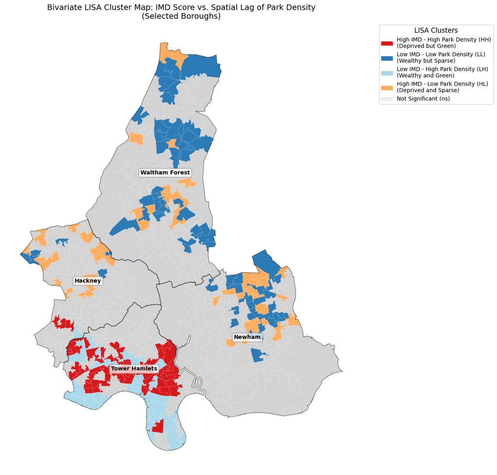

```python
import libpysal
import esda
from splot.esda import lisa_cluster
import matplotlib.pyplot as plt
import matplotlib.patches as mpatches

# 1. Calculate Park Density per LSOA
# Count the number of parks in each LSOA from our spatial join
park_counts = parks_with_imd.groupby('LSOA11CD').size().reset_index(name='park_count')

# Merge the counts back to the LSOA + IMD GeoDataFrame
lsoa_analysis_gdf = lsoa_imd_gdf.merge(park_counts, on='LSOA11CD', how='left')

# Fill NaNs with 0 (LSOAs with no parks)
lsoa_analysis_gdf['park_count'] = lsoa_analysis_gdf['park_count'].fillna(0)

# Filter to only include the boroughs we fetched park data for
target_boroughs = ["Hackney", "Kensington and Chelsea", "Tower Hamlets", "Newham", "Waltham Forest"]
lsoa_analysis_gdf = lsoa_analysis_gdf[lsoa_analysis_gdf['Local Authority District name (2019)'].isin(target_boroughs)].copy()

# Reset index to ensure weights matrix aligns perfectly
lsoa_analysis_gdf = lsoa_analysis_gdf.reset_index(drop=True)

# Calculate park density (parks per hectare)
# The CRS is EPSG:27700 (meters), so area is in square meters. 1 hectare = 10,000 sq meters.
lsoa_analysis_gdf['park_density'] = lsoa_analysis_gdf['park_count'] / (lsoa_analysis_gdf.geometry.area / 10000)

# 2. Spatial Weights Matrix
# Using K-Nearest Neighbors (KNN) instead of Queen contiguity to avoid "islands" (disconnected polygons)
# k=8 is a standard choice for polygon neighborhoods
w = libpysal.weights.KNN.from_dataframe(lsoa_analysis_gdf, k=8)
w.transform = 'r' # Row-standardize the weights

# 3. Bivariate Spatial Autocorrelation
# Variables: IMD Score (Deprivation) and Park Density
x = lsoa_analysis_gdf['Index of Multiple Deprivation (IMD) Score'].values
y = lsoa_analysis_gdf['park_density'].values

# Calculate Global Bivariate Moran's I
# This measures the correlation between a location's IMD and its neighbors' Park Density
moran_bv = esda.Moran_BV(x, y, w)
print(f"Global Bivariate Moran's I: {moran_bv.I:.3f}")
print(f"P-value: {moran_bv.p_sim:.3f}")

# Calculate Local Bivariate Moran's I (LISA)
lisa_bv = esda.Moran_Local_BV(x, y, w)

# 4. Plot LISA Map
fig, ax = plt.subplots(figsize=(12, 12))
# Disable default legend to use manual matplotlib.patches legend
plt_fig, plt_ax = lisa_cluster(lisa_bv, lsoa_analysis_gdf, p=0.05, ax=ax, legend=False)

# Add Borough Boundaries and Labels for context
# Filter the main london_gdf for our target boroughs
borough_boundaries = london_gdf[london_gdf['NAME'].isin(target_boroughs)]

# Plot the borough outlines over the LISA map
borough_boundaries.boundary.plot(ax=ax, color='black', linewidth=1, alpha=0.5)

# Add text labels for the boroughs
for idx, row in borough_boundaries.iterrows():
    # Get the centroid of the borough for label placement
    centroid = row.geometry.centroid
    ax.annotate(text=row['NAME'],
                xy=(centroid.x, centroid.y),
                xytext=(3, 3),
                textcoords="offset points",
                fontsize=10,
                fontweight='bold',
                color='black',
                ha='center',
                bbox=dict(boxstyle="round,pad=0.3", fc="white", ec="gray", alpha=0.7))

# Create custom manual legend using matplotlib.patches
legend_elements = [
    mpatches.Patch(color='#d7191c', label='High IMD - High Park Density (HH)\n(Deprived but Green)'),
    mpatches.Patch(color='#2c7bb6', label='Low IMD - Low Park Density (LL)\n(Wealthy but Sparse)'),
    mpatches.Patch(color='#abd9e9', label='Low IMD - High Park Density (LH)\n(Wealthy and Green)'),
    mpatches.Patch(color='#fdae61', label='High IMD - Low Park Density (HL)\n(Deprived and Sparse)'),
    mpatches.Patch(color='#eeeeee', label='Not Significant (ns)')
]

# Add legend to axis
ax.legend(handles=legend_elements, loc='upper left', bbox_to_anchor=(1.05, 1), title='LISA Clusters', fontsize=10, title_fontsize=12)

ax.set_title('Bivariate LISA Cluster Map: IMD Score vs. Spatial Lag of Park Density\n(Selected Boroughs)', fontsize=14)
plt.tight_layout()
plt.show()
```

# Spatial Autocorrelation Analysis

Therefore to address this, I employed **Local Indicators of Spatial Association (LISA)**. While the global trend is flat, LISA calculates a Local Moran's I for *every single LSOA individually*, allowing us to strip away the global noise as a result and thus identify statistically significant (*p < 0.05*) spatial clusters.

By utilising `libpysal` (with a KNN weights matrix to avoid geometric "islands") and `esda`, this analysis suggests that the Green Paradox is a highly localised issue, pinpointing the exact East London communities facing the highest pressure from green gentrification.

```python
park_map
```

Make this Notebook Trusted to load map: File -> Trust Notebook

[interactive chart not shown]

# Interactive Map Description

The final interactive map is built in **Folium** (essentially a Python wrapper for **Leaflet.js**), designed to make the spatial distribution easy to explore at high levels of abstraction. The map is centred using `fit_bounds` of the returned park points given a borough, which provides an automatic, data-driven extent rather some hard-coded view. A clean, neutral light basemap (`CartoDB positron`) is used so that thematic content (parks) remains visually dominant, helping support readability and avoiding unnecessary colour competition with the data layer.

Finally, `LayerControl` is included to make the map extensible (e.g adding deprivation or house-price overlays later), ensuring the interactive design can evolve into a coherent multi layer amalgamation.

Therefore, out of the **534** total mapped parks (after spatial join), **412 (77.2%)** fall within the **40%** most deprived LSOAs. Tower Hamlets alone accounted for **229 (42.8%)** of total parks but contained some of the highest IMD Scores.

# Conclusion

This project investigates the "Green Paradox", the phenomenon where urban greening inadvertently drives up gentrification and displaces vulnerable populations. By employing geovisualisation tools, I first established the socio-economic baseline of London. **Map 1** (Average House Price) & **Map 2** (Average IMD Score) revealed a stark spatial "rent gap" in East London, highlighting historically deprived areas ripe for ecological gentrification. To dynamically explore the environmental interventions driving this shift, I developed an interactive, API-driven map using **Folium** & the **OpenStreetMap Overpass API**. These visualisations help bridge the gap between static socio-economic vulnerability and real-time green infrastructure, concluding a comprehensive spatial narrative of ecological exclusion.

Specifically, each component of this analysis directly constructs the narrative of the Green Paradox:

- **The Static Socio-Economic Maps (IMD & Prices)** expose the baseline vulnerability, outlining the downturned property values and high deprivation required for the paradox to take place.
- **The Interactive Folium Map** pinpoints the spatial distribution of green amenities (the catalyst to this conondrum), revealing a disproportionate concentration of parks in historically deprived boroughs like Tower Hamlets for example.
- **The Bivariate LISA Cluster Analysis** mathematically implies the paradox by explicitly identifying the active "High-High" zones neighborhoods, where high deprivation directly intersects with high park density, marking ground zero for impending green gentrification.